# Lecture 7-1: Factors

# Factors

This chapter is based on Chapter 15 in R for Data Science and Chapter 3.4.1 in Advanced R

# Basic definitions

A factor is a vector that can contain only predefined values. It is used to store categorical data.

Factors are built on top of an integer vector with two attributes: - a class, “factor”, which makes it behave differently from regular integer vectors - levels, which define the set of allowed values.

```r
x <- factor(c("a", "b", "b", "a"))
x
```

```
## [1] a b b a
## Levels: a b
```

```r
typeof(x)
```

```
## [1] "integer"
```

```r
attributes(x)
```

```
## $levels
## [1] "a" "b"
##
## $class
## [1] "factor"
```

```r
str(x)
```

```
##  Factor w/ 2 levels "a","b": 1 2 2 1
```

Factors are useful when you know the set of possible values but they’re not all present in a given dataset. In contrast to a character vector, when you tabulate a factor you’ll get counts of all categories, even unobserved ones:

```r
(gender_char <- c("m", "m", "m"))
```

```
## [1] "m" "m" "m"
```

```r
(gender_factor <- factor(gender_char, levels = c("m", "w")))
```

```
## [1] m m m
## Levels: m w
```

```r
table(gender_char)
```

```
## gender_char
## m
## 3
```

```r
table(gender_factor)
```

```
## gender_factor
## m w
## 3 0
```

```r
gender_factor[4] <- "non-binary"
gender_factor
```

```
## [1] m    m    m    <NA>
## Levels: m w
```

```r
table(gender_factor)
```

```
## gender_factor
## m w
## 3 0
```

```r
table(gender_factor, useNA = "ifany")
```

```
## gender_factor
##    m    w <NA>
##    3    0    1
```

```r
# No longer in the 1980s:
levels(gender_factor) <- c(levels(gender_factor), "non-binary")
gender_factor[4] <- "non-binary"
gender_factor
```

```
## [1] m          m          m          non-binary
## Levels: m w non-binary
```

```r
table(gender_factor)
```

```
## gender_factor
##          m          w non-binary
##          3          0          1
```

```r
table(gender_factor, useNA = "ifany")
```

```
## gender_factor
##          m          w non-binary
##          3          0          1
```

```r
table(gender_factor, useNA = "always")
```

```
## gender_factor
##          m          w non-binary       <NA>
##          3          0          1          0
```

```r
# Back to the 1980s...
levels(gender_factor) <- c("m", "w")
```

```
## Error in `levels<-.factor`(`*tmp*`, value = c("m", "w")): number of levels differs
```

```r
gender_factor
```

```
## [1] m          m          m          non-binary
## Levels: m w non-binary
```

```r
length(gender_factor) <- 3
gender_factor
```

```
## [1] m m m
## Levels: m w non-binary
```

```r
levels(gender_factor)
```

```
## [1] "m"          "w"          "non-binary"
```

```r
gender_factor <- factor(gender_factor)

# ... and now we're stuck only with men...
gender_factor
```

```
## [1] m m m
## Levels: m
```

# Ordered factors

Ordered factors are a minor variation of factors.

- they behave like regular factors, but the order of the levels is meaningful (low, medium, high) (a property that is automatically leveraged by some modelling and visualization functions).

```r
grade <- ordered(c("b", "b", "a", "c"), levels = c("a", "b", "c"))
grade
```

```
## [1] b b a c
## Levels: a < b < c
```

```r
grade <- ordered(c("b", "b", "a", "c"), levels = c("c", "b", "a"))
grade
```

```
## [1] b b a c
## Levels: c < b < a
```

```r
str(grade)
```

```
##  Ord.factor w/ 3 levels "c"<"b"<"a": 2 2 3 1
```

In base R you tend to encounter factors very frequently because many base R functions (like read.csv() and data.frame()) automatically convert character vectors to factors.

This is suboptimal because there’s no way for those functions to know the set of all possible levels or their correct order: the levels are a property of theory or experimental design, not of the data. Instead, use the argument stringsAsFactors = FALSE to suppress this behavior, and then manually convert character vectors to factors using your knowledge of the “theoretical” data.

While factors look like (and often behave like) character vectors, they are built on top of integers. So be careful when treating them like strings. Some string methods (like gsub() and grepl()) will automatically coerce factors to strings, others (like nchar()) will throw an error, and still others will (like c()) use the underlying integer values.

For this reason, it’s usually best to explicitly convert factors to character vectors if you need string-like behavior.

```r
x
```

```
## [1] a b b a
## Levels: a b
```

```r
gsub(x, pattern = "a", replacement = "c")
```

```
## [1] "c" "b" "b" "c"
```

```r
nchar(x)
```

```
## Error in nchar(x): 'nchar()' requires a character vector
```

```r
c(x, 1)
```

```
## [1] 1 2 2 1 1
```

# Working with factors

We’ll use the `forcats` package, which is part of the core tidyverse.

```r
library(tidyverse)
```

# Creating factors

Imagine that you have a variable that records month:

```r
x1 <- c("Dec", "Apr", "Jan", "Mar")
```

Using a string to record this variable has two problems:

There are only twelve possible months, and there’s nothing saving you from typos:

```r
x2 <- c("Dec", "Apr", "Jam", "Mar")
```

It doesn’t sort in a useful way:

```r
sort(x1)
```

```
## [1] "Apr" "Dec" "Jan" "Mar"
```

You can fix both of these problems with a factor. To create a factor you must start by creating a list of the valid levels:

```r
month_levels <- c(
  "Jan", "Feb", "Mar", "Apr", "May", "Jun",
  "Jul", "Aug", "Sep", "Oct", "Nov", "Dec"
)
```

Now you can create a factor:

```r
y1 <- factor(x1, levels = month_levels)
y1
```

```
## [1] Dec Apr Jan Mar
## Levels: Jan Feb Mar Apr May Jun Jul Aug Sep Oct Nov Dec
```

```r
sort(y1)
```

```
## [1] Jan Mar Apr Dec
## Levels: Jan Feb Mar Apr May Jun Jul Aug Sep Oct Nov Dec
```

And any values not in the set will be silently converted to NA:

```r
y2 <- factor(x2, levels = month_levels)
y2
```

```
## [1] Dec  Apr  <NA> Mar
## Levels: Jan Feb Mar Apr May Jun Jul Aug Sep Oct Nov Dec
```

If you want a warning, you can use readr::parse_factor():

```r
y2 <- parse_factor(x2, levels = month_levels)
```

```
## Warning: 1 parsing failure.
## row col           expected actual
##   3  -- value in level set    Jam
```

If you omit the levels, they’ll be taken from the data in alphabetical order:

```r
factor(x1)
```

```
## [1] Dec Apr Jan Mar
## Levels: Apr Dec Jan Mar
```

To match the order of the levels with the order of the first appearance in the data. We can either:

```r
f1 <- factor(x1, levels = unique(x1))
f1
```

```
## [1] Dec Apr Jan Mar
## Levels: Dec Apr Jan Mar
```

Or post-hoc:

```r
f2 <- x1 %>% factor() %>% fct_inorder()
f2
```

```
## [1] Dec Apr Jan Mar
## Levels: Dec Apr Jan Mar
```

To access the set of valid levels directly:

```r
levels(f2)
```

```
## [1] "Dec" "Apr" "Jan" "Mar"
```

For the rest of this chapter, we’re going to focus on `forcats::gss_cat`. It’s a sample of data from the General Social Survey, which is a long-running US survey conducted by the independent research organization NORC at the University of Chicago.

The survey has thousands of questions, so in gss_cat there are a handful that will illustrate some common challenges you’ll encounter when working with factors.

```r
gss_cat
```

```
## # A tibble: 21,483 x 9
##     year marital     age race  rincome   partyid    relig   denom   tvhours
##    <int> <fct>     <int> <fct> <fct>     <fct>      <fct>   <fct>     <int>
##  1  2000 Never ma…    26 White $8000 to… Ind,near … Protes… Southe…      12
##  2  2000 Divorced     48 White $8000 to… Not str r… Protes… Baptis…      NA
##  3  2000 Widowed      67 White Not appl… Independe… Protes… No den…       2
##  4  2000 Never ma…    39 White Not appl… Ind,near … Orthod… Not ap…       4
##  5  2000 Divorced     25 White Not appl… Not str d… None    Not ap…       1
##  6  2000 Married      25 White $20000 -… Strong de… Protes… Southe…      NA
##  7  2000 Never ma…    36 White $25000 o… Not str r… Christ… Not ap…       3
##  8  2000 Divorced     44 White $7000 to… Ind,near … Protes… Luther…      NA
##  9  2000 Married      44 White $25000 o… Not str d… Protes… Other         0
## 10  2000 Married      47 White $25000 o… Strong re… Protes… Southe…       3
## # … with 21,473 more rows
```

(To get more information about the variables use ?gss_cat.)

gss_cat is a tibble.

When factors are stored in a tibble, you can’t see their levels so easily. One way to see them is with count():

```r
gss_cat %>%
  count(race)
```

```
## # A tibble: 3 x 2
##   race      n
## * <fct> <int>
## 1 Other  1959
## 2 Black  3129
## 3 White 16395
```

Or with a bar chart:

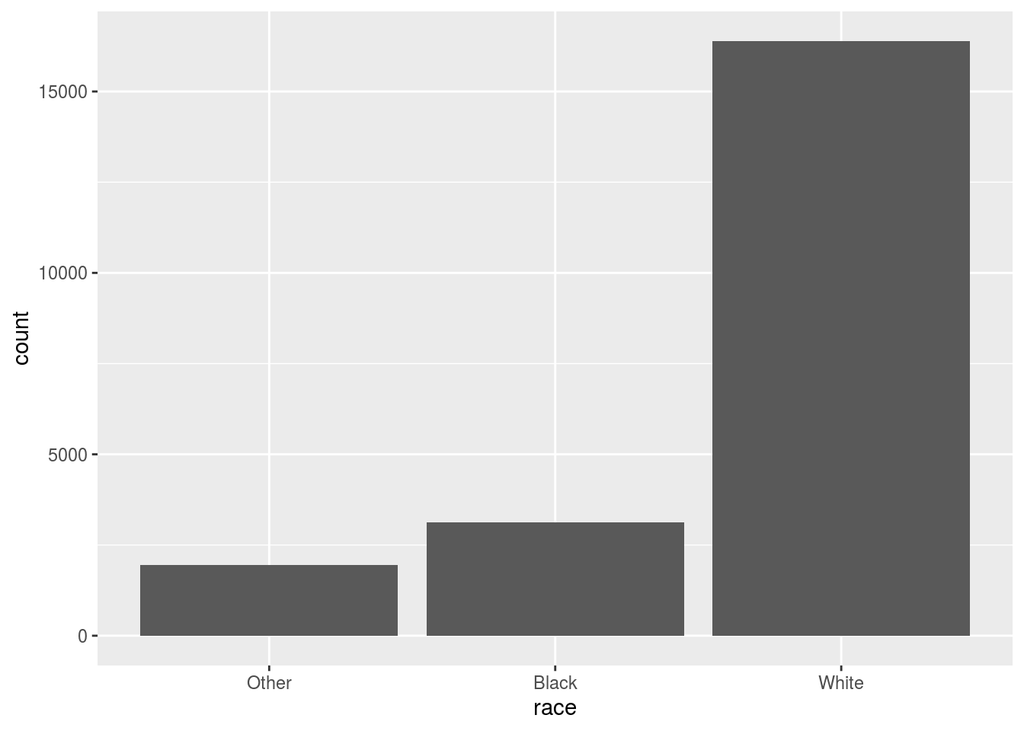

```r
ggplot(gss_cat, aes(race)) +
  geom_bar()
```

By default, `ggplot2` and `count()` will drop levels that don’t have any values. These levels still represent valid values that simply did not occur in this dataset.

You can force them to display with:

```r
gss_cat %>%
  count(race, .drop = FALSE)
```

```
## # A tibble: 4 x 2
##   race               n
## * <fct>          <int>
## 1 Other           1959
## 2 Black           3129
## 3 White          16395
## 4 Not applicable     0
```

What should happen when we use `.drop = FALSE` with two variables?

```r
gss_cat %>%
  count(race, year, .drop = FALSE) %>%
  tail(n = 15)
```

```
## # A tibble: 15 x 3
##    race            year     n
##    <fct>          <int> <int>
##  1 Black           2004   377
##  2 Black           2006   634
##  3 Black           2008   281
##  4 Black           2010   311
##  5 Black           2012   301
##  6 Black           2014   386
##  7 White           2000  2213
##  8 White           2002  2188
##  9 White           2004  2234
## 10 White           2006  3284
## 11 White           2008  1559
## 12 White           2010  1550
## 13 White           2012  1477
## 14 White           2014  1890
## 15 Not applicable    NA     0
```

Not ideal. That is because `year` is not a factor. Try:

```r
gss_cat %>%
  count(race, factor(year), .drop = FALSE) %>%
  tail(n = 15)
```

```
## # A tibble: 15 x 3
##    race           `factor(year)`     n
##    <fct>          <fct>          <int>
##  1 White          2002            2188
##  2 White          2004            2234
##  3 White          2006            3284
##  4 White          2008            1559
##  5 White          2010            1550
##  6 White          2012            1477
##  7 White          2014            1890
##  8 Not applicable 2000               0
##  9 Not applicable 2002               0
## 10 Not applicable 2004               0
## 11 Not applicable 2006               0
## 12 Not applicable 2008               0
## 13 Not applicable 2010               0
## 14 Not applicable 2012               0
## 15 Not applicable 2014               0
```

`.drop = FALSE` works as you hope it would with two (or more) variables only when both (or all) are factors.

Another way: more explicitly (the `.drop` argument really belongs to `group_by`):

```r
gss_cat %>%
  group_by(race, .drop = FALSE) %>%
  summarise(n = n())
```

```
## # A tibble: 4 x 2
##   race               n
## * <fct>          <int>
## 1 Other           1959
## 2 Black           3129
## 3 White          16395
## 4 Not applicable     0
```

or with a bar plot:

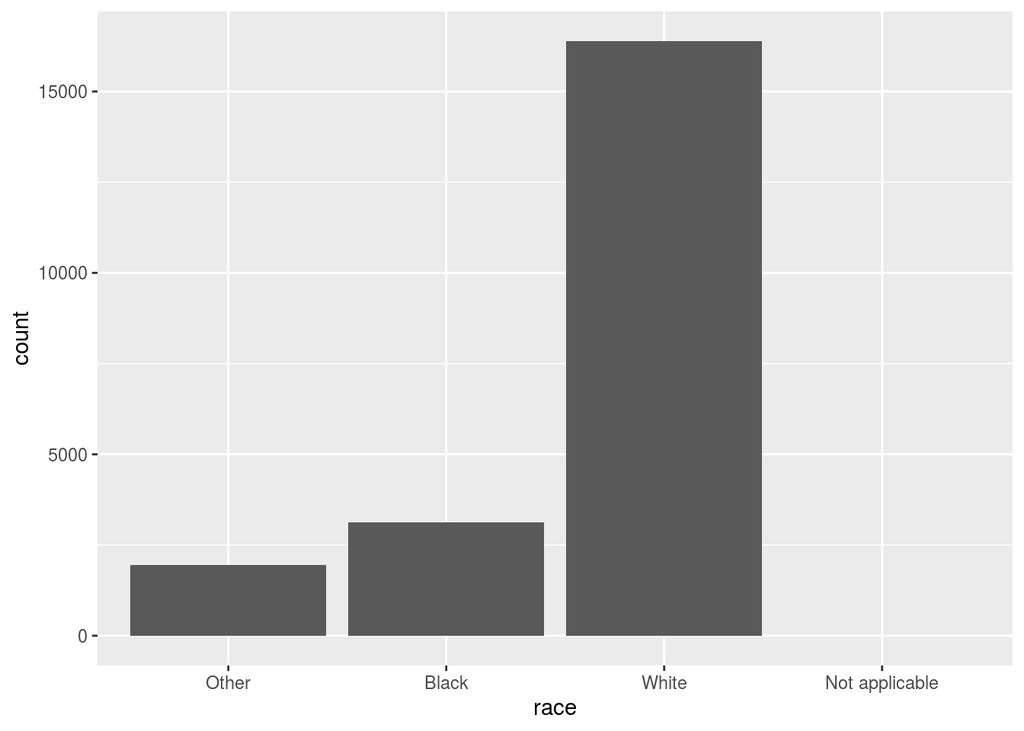

```r
ggplot(gss_cat, aes(race)) +
  geom_bar() +
  scale_x_discrete(drop = FALSE)
```

```r
table(gss_cat$race)
```

```
##
##          Other          Black          White Not applicable
##           1959           3129          16395              0
```

and to complete the presentation, you can also use base R graphics `barplot()`:

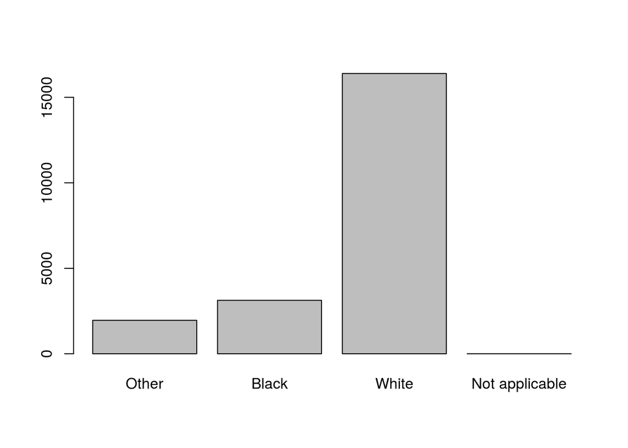

```r
barplot(table(gss_cat$race))
```

# Exercises

Based on the last example, what is the difference between the default usages for `barplot()` and `geom_bar()`? Provide a ggplot that performs the same as base barplot (note, you can transform a data frame with dplyr and use another pipe operator to send it to ggplot)

Explore the distribution of rincome (reported income). What makes the default bar chart hard to understand? How could you improve the plot?

What are the different categories for `relig`? For `partyid`?

What is the most common relig in this survey? What’s the most common partyid? What is the most common combination of the two?

Which relig does denom (denomination) apply to? How can you find out with a `dplyr` verbs? with `table()`? How can you find out with a visualization?

What’s going on with “Christian”s? Who are the “Other”s that have denomination?

# Modifying factor order

It’s often useful to change the order of the factor levels in a visualization. For example, imagine you want to explore the average number of hours spent watching TV per day across religions:

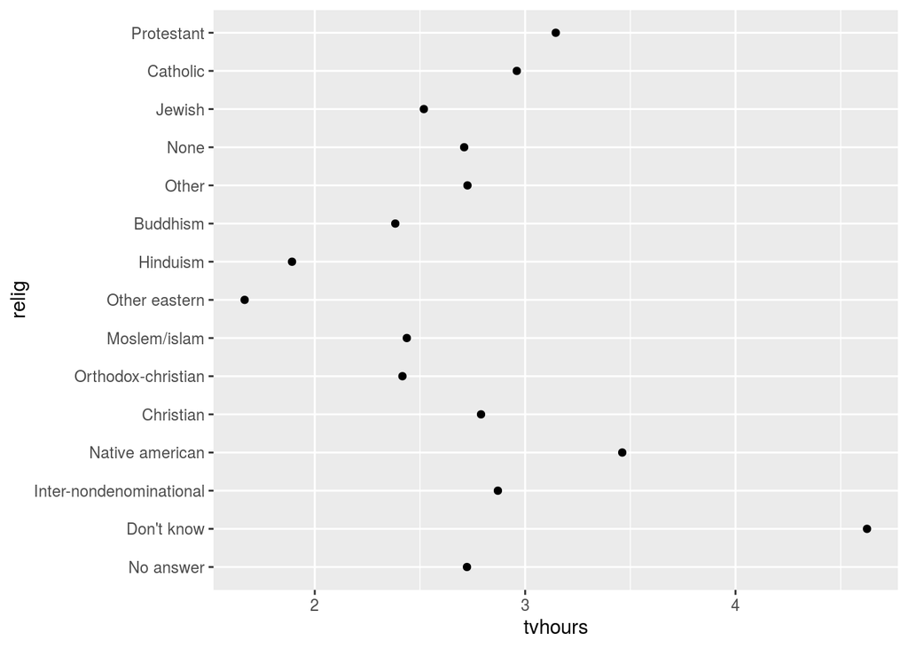

```r
relig_summary <- gss_cat %>%
  group_by(relig) %>%
  summarise(tvhours = mean(tvhours, na.rm = TRUE))

ggplot(relig_summary, aes(tvhours, relig)) + geom_point()
```

It is difficult to interpret this plot because there’s no overall pattern. We can improve it by reordering the levels of relig using fct_reorder(). fct_reorder() takes three arguments:

```
f, the factor whose levels you want to modify.
x, a numeric vector that you want to use to reorder the levels.
Optionally, fun, a function that’s used if there are multiple values of x for each value of f. The default value is median.
```

```r
relig_summary
```

```
## # A tibble: 15 x 2
##    relig                   tvhours
##  * <fct>                     <dbl>
##  1 No answer                  2.72
##  2 Don't know                 4.62
##  3 Inter-nondenominational    2.87
##  4 Native american            3.46
##  5 Christian                  2.79
##  6 Orthodox-christian         2.42
##  7 Moslem/islam               2.44
##  8 Other eastern              1.67
##  9 Hinduism                   1.89
## 10 Buddhism                   2.38
## 11 Other                      2.73
## 12 None                       2.71
## 13 Jewish                     2.52
## 14 Catholic                   2.96
## 15 Protestant                 3.15
```

```r
relig_summary %>%
  mutate(relig = fct_reorder(relig, tvhours))
```

```
## # A tibble: 15 x 2
##    relig                   tvhours
##  * <fct>                     <dbl>
##  1 No answer                  2.72
##  2 Don't know                 4.62
##  3 Inter-nondenominational    2.87
##  4 Native american            3.46
##  5 Christian                  2.79
##  6 Orthodox-christian         2.42
##  7 Moslem/islam               2.44
##  8 Other eastern              1.67
##  9 Hinduism                   1.89
## 10 Buddhism                   2.38
## 11 Other                      2.73
## 12 None                       2.71
## 13 Jewish                     2.52
## 14 Catholic                   2.96
## 15 Protestant                 3.15
```

Let’s examine the effect of fct_reorder:

First, on the factor as it is printed:

```r
relig_summary$relig
```

```
##  [1] No answer               Don't know
##  [3] Inter-nondenominational Native american
##  [5] Christian               Orthodox-christian
##  [7] Moslem/islam            Other eastern
##  [9] Hinduism                Buddhism
## [11] Other                   None
## [13] Jewish                  Catholic
## [15] Protestant
## 16 Levels: No answer Don't know ... Not applicable
```

```r
fct_reorder(relig_summary$relig, relig_summary$tvhours)
```

```
##  [1] No answer               Don't know
##  [3] Inter-nondenominational Native american
##  [5] Christian               Orthodox-christian
##  [7] Moslem/islam            Other eastern
##  [9] Hinduism                Buddhism
## [11] Other                   None
## [13] Jewish                  Catholic
## [15] Protestant
## 16 Levels: Other eastern Hinduism Buddhism ... Not applicable
```

Focus on the levels:

```r
levels(relig_summary$relig)
```

```
##  [1] "No answer"               "Don't know"
##  [3] "Inter-nondenominational" "Native american"
##  [5] "Christian"               "Orthodox-christian"
##  [7] "Moslem/islam"            "Other eastern"
##  [9] "Hinduism"                "Buddhism"
## [11] "Other"                   "None"
## [13] "Jewish"                  "Catholic"
## [15] "Protestant"              "Not applicable"
```

```r
levels(fct_reorder(relig_summary$relig, relig_summary$tvhours))
```

```
##  [1] "Other eastern"           "Hinduism"
##  [3] "Buddhism"                "Orthodox-christian"
##  [5] "Moslem/islam"            "Jewish"
##  [7] "None"                    "No answer"
##  [9] "Other"                   "Christian"
## [11] "Inter-nondenominational" "Catholic"
## [13] "Protestant"              "Native american"
## [15] "Don't know"              "Not applicable"
```

The printed values didn’t change:

```r
relig_summary$relig == fct_reorder(relig_summary$relig, relig_summary$tvhours)
```

```
##  [1] TRUE TRUE TRUE TRUE TRUE TRUE TRUE TRUE TRUE TRUE TRUE TRUE TRUE TRUE
## [15] TRUE
```

But, the underlying integer vector HAS changed:

```r
as.integer(relig_summary$relig)
```

```
##  [1]  1  2  3  4  5  6  7  8  9 10 11 12 13 14 15
```

```r
as.integer(fct_reorder(relig_summary$relig, relig_summary$tvhours))
```

```
##  [1]  8 15 11 14 10  4  5  1  2  3  9  7  6 12 13
```

```r
as.integer(relig_summary$relig) == as.integer(fct_reorder(relig_summary$relig, relig_summary$tvhours))
```

```
##  [1] FALSE FALSE FALSE FALSE FALSE FALSE FALSE FALSE FALSE FALSE FALSE
## [12] FALSE FALSE FALSE FALSE
```

Plot it!

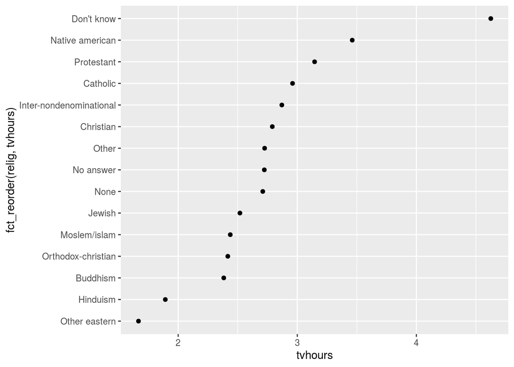

```r
ggplot(relig_summary, aes(tvhours, fct_reorder(relig, tvhours))) +
  geom_point()
```

In descending order:

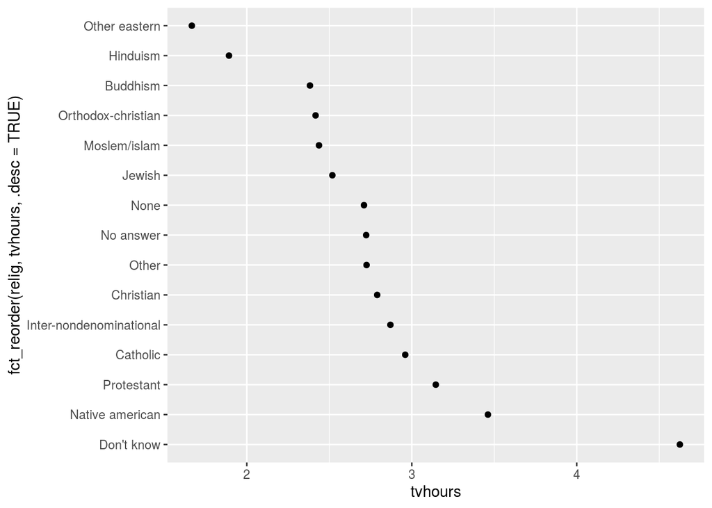

```r
ggplot(relig_summary, aes(tvhours, fct_reorder(relig, tvhours, .desc = TRUE))) +
  geom_point()
```

Reordering religion makes it much easier to see that people in the “Don’t know” category watch much more TV, and Hinduism & Other Eastern religions watch much less.

As you start making more complicated transformations, you could move them out of aes() and into a separate mutate() step. For example:

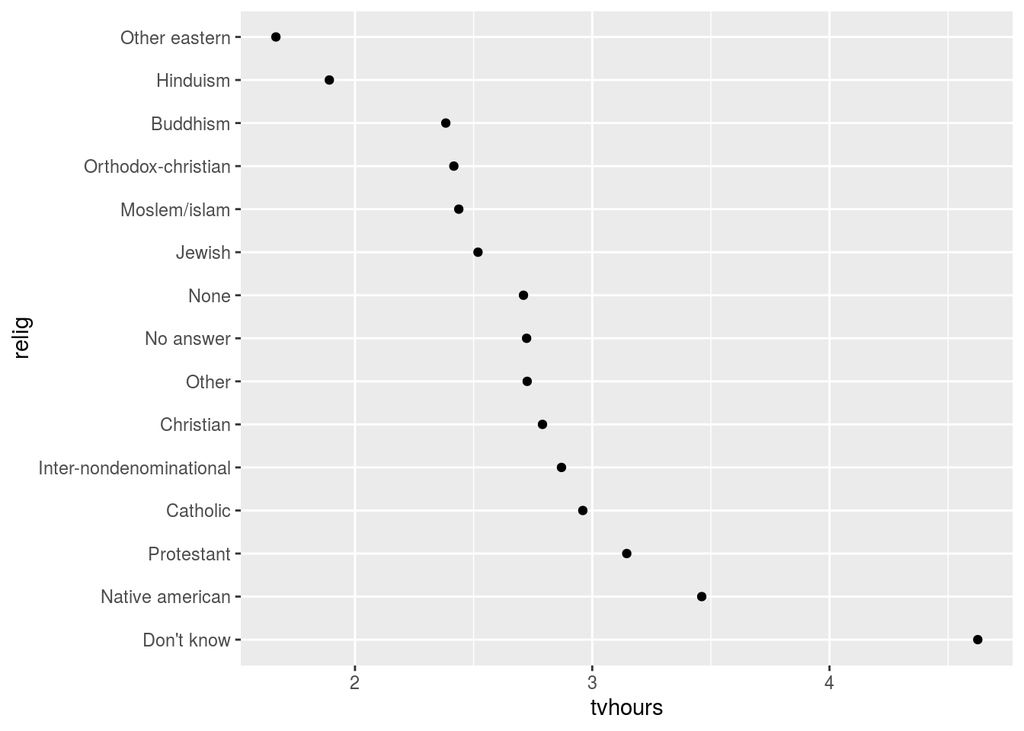

```r
relig_summary %>%
  mutate(relig = fct_reorder(relig, tvhours, .desc = TRUE)) %>%
  ggplot(aes(tvhours, relig)) +
    geom_point()
```

What changed? Nothing, except the y-axis title.

What if we create a similar plot looking at how average age varies across reported income level?

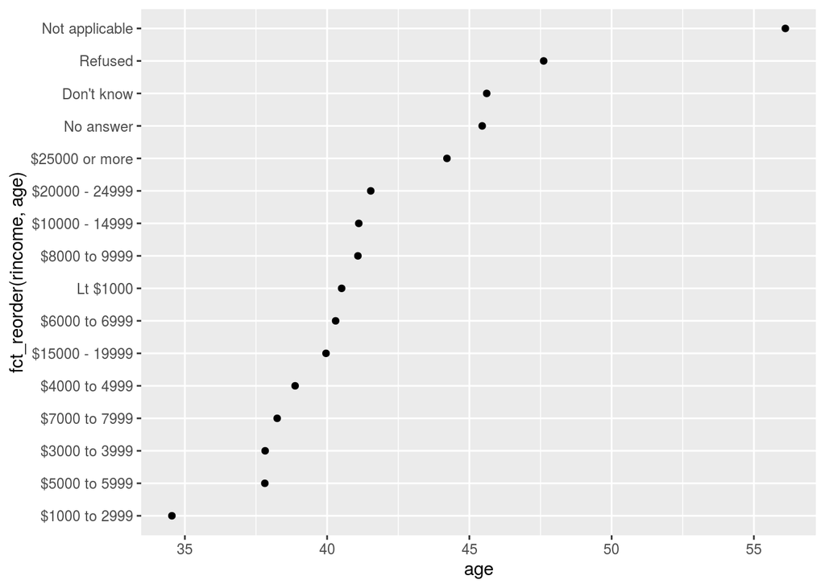

```r
rincome_summary <- gss_cat %>%
  group_by(rincome) %>%
  summarise(
    age = mean(age, na.rm = TRUE)
  )

ggplot(rincome_summary, aes(age, fct_reorder(rincome, age))) + geom_point()
```

Here, arbitrarily reordering the levels isn’t a good idea! That’s because rincome already has a principled order that we shouldn’t mess with.

Reserve fct_reorder() for factors whose levels are arbitrarily ordered.

However, it does make sense to pull “Not applicable” to the front with the other special levels. You can use fct_relevel(). It takes a factor, f, and then any number of levels that you want to move to the front of the line.

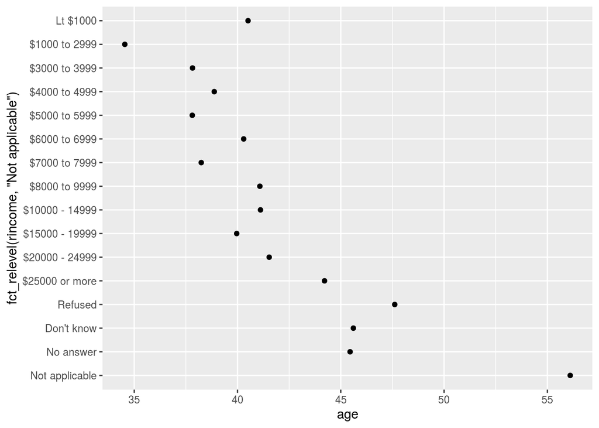

```r
ggplot(rincome_summary, aes(age, fct_relevel(rincome, "Not applicable"))) +
  geom_point()
```

To illustrate more sharply:

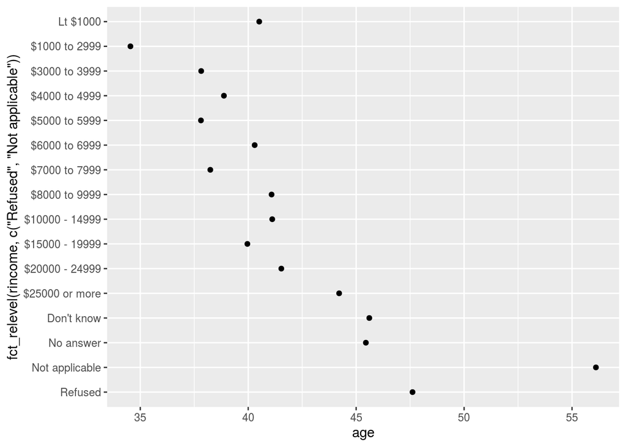

```r
ggplot(rincome_summary, aes(age, fct_relevel(rincome, c("Refused", "Not applicable")))) +
  geom_point()
```

Another type of reordering is useful when you are coloring the lines on a plot. fct_reorder2() reorders the factor by the y values associated with the largest x values. This makes the plot easier to read because the line colors line up with the legend.

```r
by_age <- gss_cat %>%
  filter(!is.na(age)) %>%
  count(age, marital) %>%
  group_by(age) %>%
  mutate(prop = n / sum(n))
by_age
```

```
## # A tibble: 351 x 4
## # Groups:   age [72]
##      age marital           n    prop
##    <int> <fct>         <int>   <dbl>
##  1    18 Never married    89 0.978
##  2    18 Married           2 0.0220
##  3    19 Never married   234 0.940
##  4    19 Divorced          3 0.0120
##  5    19 Widowed           1 0.00402
##  6    19 Married          11 0.0442
##  7    20 Never married   227 0.904
##  8    20 Separated         1 0.00398
##  9    20 Divorced          2 0.00797
## 10    20 Married          21 0.0837
## # … with 341 more rows
```

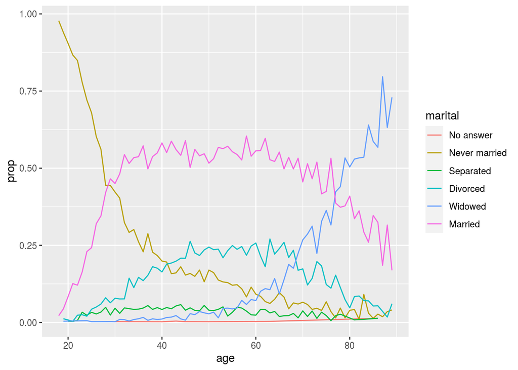

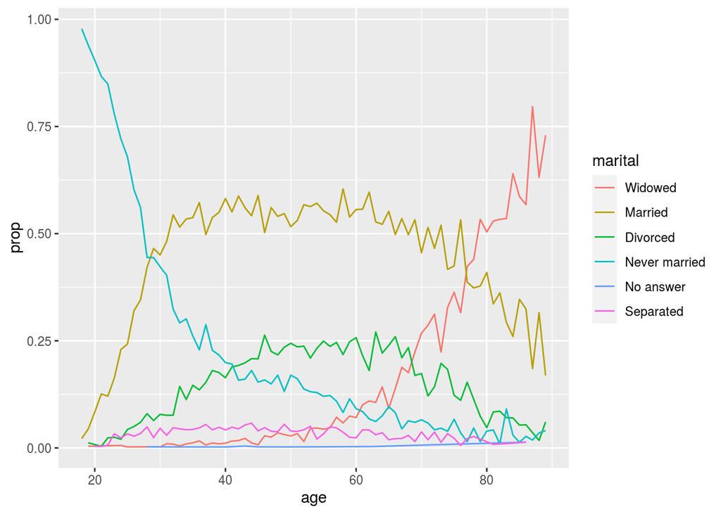

```r
ggplot(by_age, aes(age, prop, colour = marital)) +
  geom_line(na.rm = TRUE)

ggplot(by_age, aes(age, prop, colour = fct_reorder2(marital, age, prop))) +
  geom_line() +
  labs(colour = "marital")
```

Finally, for bar plots, you can use fct_infreq() to order levels in increasing frequency: this is the simplest type of reordering because it doesn’t need any extra variables. You may want to combine with fct_rev().

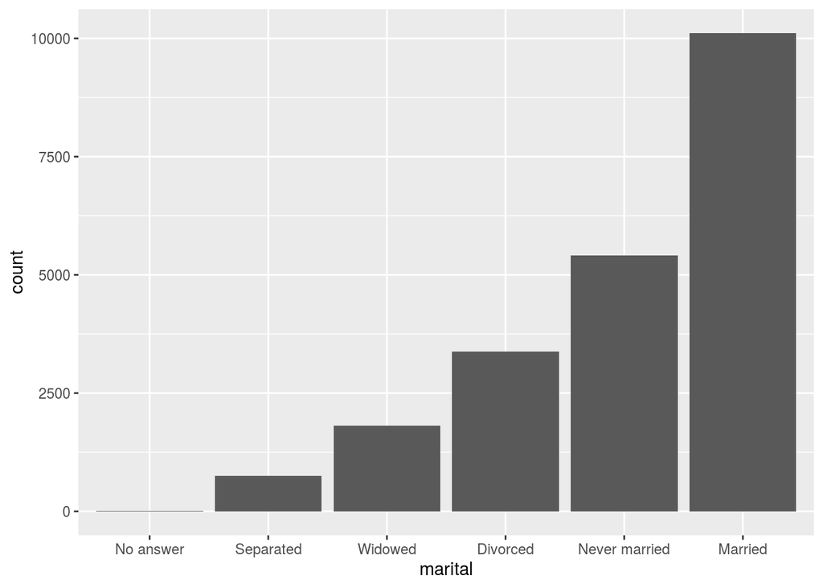

```r
gss_cat %>%
  mutate(marital = marital %>% fct_infreq() %>% fct_rev()) %>%
  ggplot(aes(marital)) +
    geom_bar()
```

# Exercises

For each factor in gss_cat identify whether the order of the levels is arbitrary or principled. Can you reliably use the `is.ordered()` function here?

# Modifying factor levels

More powerful than changing the orders of the levels is changing their values. This allows you to clarify labels for publication, and collapse levels for high-level displays. The most general and powerful tool is fct_recode(). It allows you to recode, or change, the value of each level. For example, take the gss_cat$partyid:

```r
gss_cat %>% count(partyid)
```

```
## # A tibble: 10 x 2
##    partyid                n
##  * <fct>              <int>
##  1 No answer            154
##  2 Don't know             1
##  3 Other party          393
##  4 Strong republican   2314
##  5 Not str republican  3032
##  6 Ind,near rep        1791
##  7 Independent         4119
##  8 Ind,near dem        2499
##  9 Not str democrat    3690
## 10 Strong democrat     3490
```

The levels are terse and inconsistent. Let’s tweak them to be longer and use a parallel construction.

```r
gss_cat %>%
  mutate(partyid = fct_recode(partyid,
    "Republican, strong"    = "Strong republican",
    "Republican, weak"      = "Not str republican",
    "Independent, near rep" = "Ind,near rep",
    "Independent, near dem" = "Ind,near dem",
    "Democrat, weak"        = "Not str democrat",
    "Democrat, strong"      = "Strong democrat"
  )) %>%
  count(partyid)
```

```
## # A tibble: 10 x 2
##    partyid                   n
##  * <fct>                 <int>
##  1 No answer               154
##  2 Don't know                1
##  3 Other party             393
##  4 Republican, strong     2314
##  5 Republican, weak       3032
##  6 Independent, near rep  1791
##  7 Independent            4119
##  8 Independent, near dem  2499
##  9 Democrat, weak         3690
## 10 Democrat, strong       3490
```

fct_recode() will leave levels that aren’t explicitly mentioned as is, and will warn you if you accidentally refer to a level that doesn’t exist.

To combine groups, you can assign multiple old levels to the same new level:

```r
gss_cat %>%
  mutate(partyid = fct_recode(partyid,
    "Republican, strong"    = "Strong republican",
    "Republican, weak"      = "Not str republican",
    "Independent, near rep" = "Ind,near rep",
    "Independent, near dem" = "Ind,near dem",
    "Democrat, weak"        = "Not str democrat",
    "Democrat, strong"      = "Strong democrat",
    "Other"                 = "No answer",
    "Other"                 = "Don't know",
    "Other"                 = "Other party"
  )) %>%
  count(partyid)
```

```
## # A tibble: 8 x 2
##   partyid                   n
## * <fct>                 <int>
## 1 Other                   548
## 2 Republican, strong     2314
## 3 Republican, weak       3032
## 4 Independent, near rep  1791
## 5 Independent            4119
## 6 Independent, near dem  2499
## 7 Democrat, weak         3690
## 8 Democrat, strong       3490
```

You must use this technique with care: if you group together categories that are truly different you will end up with misleading results.

If you want to collapse a lot of levels, fct_collapse() is a useful variant of fct_recode(). For each new variable, you can provide a vector of old levels:

```r
gss_cat %>%
  mutate(partyid = fct_collapse(partyid,
    other = c("No answer", "Don't know", "Other party"),
    rep = c("Strong republican", "Not str republican"),
    ind = c("Ind,near rep", "Independent", "Ind,near dem"),
    dem = c("Not str democrat", "Strong democrat")
  )) %>%
  count(partyid)
```

```
## # A tibble: 4 x 2
##   partyid     n
## * <fct>   <int>
## 1 other     548
## 2 rep      5346
## 3 ind      8409
## 4 dem      7180
```

Sometimes you just want to lump together all the small groups to make a plot or table simpler. That’s the job of fct_lump():

```r
gss_cat %>%
  mutate(relig = fct_lump(relig)) %>%
  count(relig)
```

```
## # A tibble: 2 x 2
##   relig          n
## * <fct>      <int>
## 1 Protestant 10846
## 2 Other      10637
```

The default behavior is to progressively lump together the smallest groups, ensuring that the aggregate is still the smallest group. In this case it’s not very helpful: it is true that the majority of Americans in this survey are Protestant, but we’ve probably over collapsed.

Instead, we can use the n parameter to specify how many groups (excluding other) we want to keep:

```r
gss_cat %>%
  mutate(relig = fct_lump(relig, n = 10)) %>%
  count(relig, sort = TRUE)
```

```
## # A tibble: 10 x 2
##    relig                       n
##    <fct>                   <int>
##  1 Protestant              10846
##  2 Catholic                 5124
##  3 None                     3523
##  4 Christian                 689
##  5 Other                     458
##  6 Jewish                    388
##  7 Buddhism                  147
##  8 Inter-nondenominational   109
##  9 Moslem/islam              104
## 10 Orthodox-christian         95
```

# Exercises

How have the proportions of people identifying as Democrat, Republican, and Independent changed over time?

Why shouldn’t you use `fct_lump` to collapse rincome to fewer levels?